# PEC1

Jairo Aguirre

NOV-2024

## 1. Resumen

En esta prueba de evaluación continua hemos creado un contenedor del tipo SummarizedExperiment que contiene datos y metadatos de un dataset que ha sido descargado del repositoriodel [repositorio de github](https://github.com/nutrimetabolomics/metaboData/tree/main/Datasets/2023-CIMCBTutorial). Se ha llevado a cabo una exploración del dataset, proporcionando una visión general sobre cómo trabajar con este tipo de clases en R.

El proceso para explorar los datos fue el siguiente:

1. Descargar los datos del repositorio GitHub
2. Crear nuestro SummarizedExperiment
3. Explorar el objeto (se) para entender su estructura y contenido
4. Visualizar y explicar algunos de los resultados observados

## 2. Objetivos

El objetivo principal de esta actividad es consolidar los conocimientos y competencias adquiridos sobre los diferentes tipos de herramientas y su manejo bioinformático con herramientas como Galaxy o Bioconductor, a través del estudio de un SummarizedExperiment creado a partir de un dataset.

Adicionalmente, se evaluará la calidad de los datos utilizando las métricas Perc_missing y QC_RSD, las cuales se explican más adelante.

## 3. Preparación del sistema

#### 3.1 Instalación y carga de paquetes

Cargamos las librerías necesarias para la realización de esta PEC

```r
library(readxl)
library(SummarizedExperiment)
```

### 3.2 Preparar los componentes de nuestra clase

Lo primero que hacemos es leer los datos con los que trabajaremos. Nuesto excel contiene dos hojas, por lo tanto asignaremos cada hoja a un objeto.

```r
#Hoja 1
data <- read_excel("~/MÁSTER/ANÁLISIS DATOS ÓMICOS/PEC1/GastricCancer_NMR.xlsx", sheet = "Data")

#Hoja 2
peak <- read_excel("~/MÁSTER/ANÁLISIS DATOS ÓMICOS/PEC1/GastricCancer_NMR.xlsx", sheet = "Peak")
```

Para crear nuestra clase debemos separar nuestros datos de expresión (assays) y los metadatos (información fenotípica o covariables de las muestras).

Los datos de expresión los encontramos en la hoja 1 y se corresponden con las columnas que contienen los valores númericos (M1 - M149)

```r
assay_data <- as.matrix(data[, grep("^M", names(data))])
```

### 3.3 Creación de nuestra clase

Ahora procedemos a crear nuestra clase SummarizedExperiment

```r
se <- SummarizedExperiment(assays = list(counts = assay_data),
                           colData = peak)
```

Con rowData vamos a añadir caracteristicas de cada muestra

```r
row_data <- data[, c("Idx", "SampleID", "SampleType", "Class")]
```

Vamos a visualizar las características de nuestro objeto

```r
se <- SummarizedExperiment(assays = list(counts = assay_data),
                             rowData = row_data,
                             colData = peak)
se
```

```
## class: SummarizedExperiment
## dim: 140 149
## metadata(0):
## assays(1): counts
## rownames: NULL
## rowData names(4): Idx SampleID SampleType Class
## colnames(149): M1 M2 ... M148 M149
## colData names(5): Idx Name Label Perc_missing QC_RSD
```

Podemos observar que nuestra clase tiene unas dimensiones de 140 filas y 149 columnas, donde las filas representan las distintas muestras y las columnas los metabolitos.

## 4 Exploración del SummarizedExperiment

Cuando ejecutamos class(colData(se)) obtenemos la clase del elemento colData en el objeto SummarizedExperiment (se).

```r
class(colData(se))
```

```
## [1] "DFrame"
## attr(,"package")
## [1] "S4Vectors"
```

DFrame es el tipo de clase de colData(se). DFrame es una estructura de datos específica del paquete S4Vectors en R, que se usa comúnmente en objetos SummarizedExperiment para almacenar metadatos asociados con muestras (Roland, 2013)

Podemos observar las primeras filas de nuestro colData

```r
head(colData(se))
```

```
## DataFrame with 6 rows and 5 columns
##          Idx        Name                  Label Perc_missing    QC_RSD
##    <numeric> <character>            <character>    <numeric> <numeric>
## M1         1          M1      1_3-Dimethylurate    11.428571  32.20800
## M2         2          M2 1_6-Anhydro-β-D-gluc..     0.714286  31.17803
## M3         3          M3   1_7-Dimethylxanthine     5.000000  34.99060
## M4         4          M4   1-Methylnicotinamide     8.571429  12.80420
## M5         5          M5         2-Aminoadipate     1.428571   9.37266
## M6         6          M6        2-Aminobutyrate     5.000000  46.97715
```

Cada fila representa un metabolito diferente identificado en las muestras, y las columnas contienen metadatos asociados:

- Idx: Es un identificador numérico único para cada metabolito.
- Name: Se corresponde con el nombre del metabolito que se está midiendo en el análisis.
- Label: Este campo proporciona una descripción adicional del metabolito.
- Perc_missing: Indica el porcentaje de datos faltantes para ese metabolito en todas las muestras. Es decir, en que porcentaje no están presentes o no se detectaron el metabolito en las muestras totales.
- QC_RSD: Representa el control de calidad, a mayor porcentaj más variablidad lo que podría indicar probelams de detección o cuantificación.

```r
head(assay(se))
```

```
##         M1      M2    M3   M4    M5    M6    M7    M8    M9   M10    M11   M12
## [1,]  90.1   491.6 202.9 35.0 164.2  19.7  41.0  46.5  17.3 106.8   61.7  75.3
## [2,]  43.0   525.7 130.2   NA 694.5 114.5  37.9 125.7  57.8    NA  490.6 203.4
## [3,] 214.3 10703.2 104.7 46.8 483.4 152.3 110.1  85.1 238.3  48.0 2441.2 100.0
## [4,]  31.6    59.7  86.4 14.0  88.6  10.3 170.3  23.9    NA    NA  140.7  12.6
## [5,]  81.9   258.7 315.1  8.7 243.2  18.4 349.4  61.1  12.2  72.9   48.7  57.3
## [6,] 196.9   128.2 862.5 18.7 200.1   4.7  37.3 243.7 293.3 113.1  103.7 116.6
##        M13  M14   M15   M16  M17   M18   M19   M20   M21   M22   M23   M24  M25
## [1,]  79.7 35.3  28.8 245.9  5.8 122.2  90.9  47.0  49.0  37.2 422.0 155.1 21.4
## [2,] 330.8   NA 210.7 150.3 71.5 553.1 217.7 207.9 238.8 297.2 591.2 446.4 28.3
## [3,] 873.3 29.3  45.4 226.4 36.3 371.9  98.1 116.5  30.3  24.6 593.4 232.6 35.1
## [4,]  46.3 62.9  38.3  49.7  0.4  31.3  38.6  53.2  45.4   3.7 130.1   1.6 26.6
## [5,] 140.1 77.8  51.0  71.3 18.8 265.0  84.7  78.8 141.3  58.0 722.1 174.7 58.9
## [6,]  81.7 52.3  76.8 273.5 45.8 394.7  66.9  63.0 101.1  96.6 640.5  74.8 29.1
##       M26   M27    M28   M29  M30    M31   M32   M33   M34    M35   M36   M37
```

[output cut: 76 more lines]

Cada celda en esta matriz contiene el valor cuantificado de un metabolito específico en una muestra particular.

Al ejecutar head(rowData()) observaremos las primeras filas de una matriz que nos ofrece información descriptiva específica sobre las muestras.

```r
head(rowData(se))
```

```
## DataFrame with 6 rows and 4 columns
##         Idx    SampleID  SampleType       Class
##   <numeric> <character> <character> <character>
## 1         1    sample_1          QC          QC
## 2         2    sample_2      Sample          GC
## 3         3    sample_3      Sample          BN
## 4         4    sample_4      Sample          HE
## 5         5    sample_5      Sample          GC
## 6         6    sample_6      Sample          BN
```

- Idx: Es una columna numérica que indica un identificador para cada muestra.
- SampleID: Código único que identifica cada muestra.
- SampleType: Clasificación del tipo de muestra. “QC” (Quality Control, usadas para verificar la precisión y reproducibilidad del análisis) o “Sample” (muestras experimentales del estudio).
- Class: Grupo o categoría de cada muestra dentro del experimento.

## 5.Resultados

Una vez tenemos clara esta información, podríamos inferir:

```r
colData(se)[1, ]
```

```
## DataFrame with 1 row and 5 columns
##          Idx        Name             Label Perc_missing    QC_RSD
##    <numeric> <character>       <character>    <numeric> <numeric>
## M1         1          M1 1_3-Dimethylurate      11.4286    32.208
```

Por ejemplo, el valor de 11.428571 en la primera fila significa que aproximadamente el 11.43% de las mediciones para “1_3-Dimethylurate” no están presentes o no se detectaron.

```r
colData(se)[6, ]
```

```
## DataFrame with 1 row and 5 columns
##          Idx        Name           Label Perc_missing    QC_RSD
##    <numeric> <character>     <character>    <numeric> <numeric>
## M6         6          M6 2-Aminobutyrate            5   46.9771
```

El metabolito “2-Aminobutyrate” presenta un valor de QC_RSD de 46.9771 lo que podría indicar mayor variabilidad y posibles problemas en la detección o cuantificación.

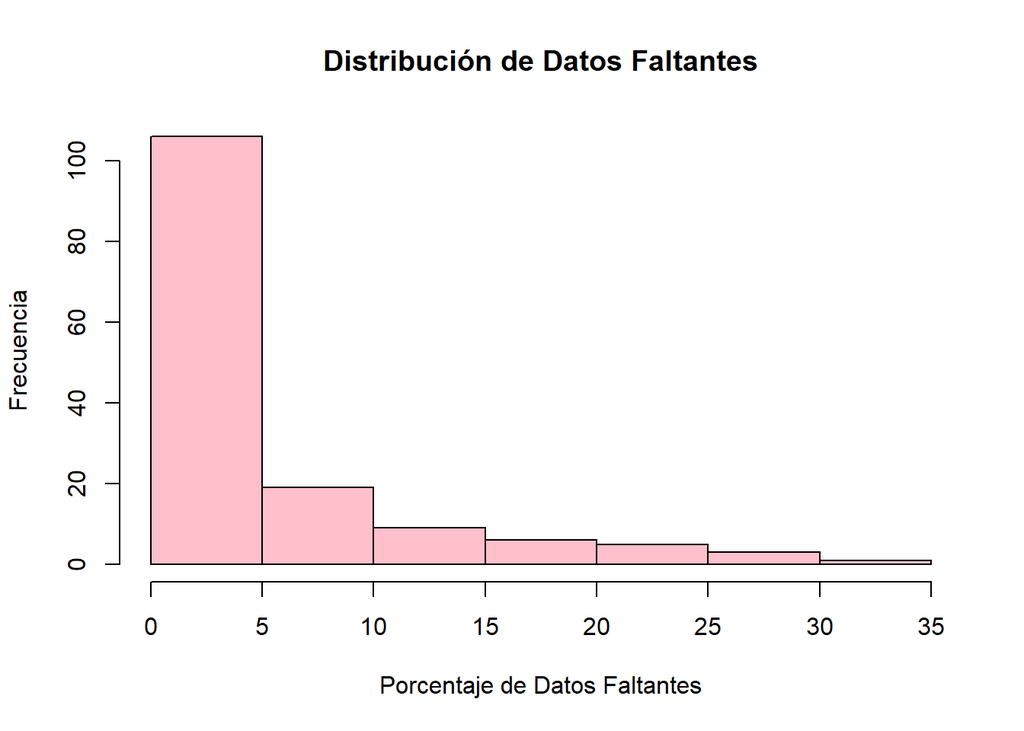

```r
hist(peak$Perc_missing, main="Distribución de Datos Faltantes", xlab="Porcentaje de Datos Faltantes", ylab="Frecuencia", col="pink")
```

Un alto porcentaje de datos faltantes puede indicar problemas en el proceso de adquisición de datos.

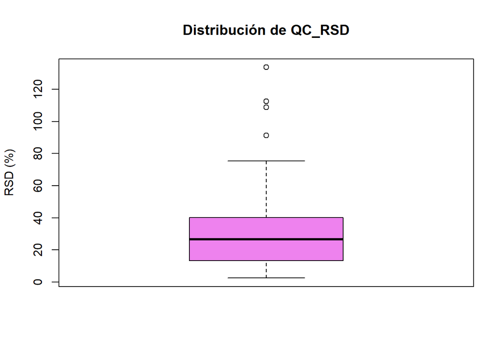

```r
boxplot(peak$QC_RSD, main="Distribución de QC_RSD", ylab="RSD (%)", col="violet")
```

Un valor alto de QC_RSD puede sugerir inconsistencias en la cuantificación de los metabolitos.

Para este conjunto de datos, los investigadores calcularon estadísticas básicas y se almecenaron en la tabla de picos (peak-hoja 2), Los investigadores solo aceptaron los metabolitos que cumplían:

- una desviación estándar de control de calidad (QC-RSD) inferior al 20 %
- que el valor de datos faltantes fuesen menor del 10

## 6. Discusión

En esta actividad, se ha creado un contenedor SummarizedExperiment que permite integrar datos y metadatos obtenidos de un análisis de metabolómica. La exploración realizada ha proporcionado una visión clara sobre la estructura de los datos y ha facilitado identificación relevante de patrones en los metabolitos analizados.

La interpretación biológica de estos resultados puede ser compleja. Los metabolitos pueden estar influenciados por múltiples factores, como la dieta, el estilo de vida y condiciones ambientales, lo que complica su análisis. Hay que tener en cuenta n tamaño de muestra insuficiente puede limitar la capacidad de generalizar los resultados y afectar la validez estadística de las conclusiones (Sigma-Aldrich, n.d).

Esta actividad demuestra la utilidad de los objetos SummarizedExperiment para manejar datos de metabolómica de manera eficiente. La integración de datos y metadatos en un único objeto facilita la interpretación y el análisis posterior.

## 7. Referencias

Roland (2013). What is the practical difference between data.frame and data.table in R? Stack Overflow. Retrieved from https://stackoverflow.com/questions/18001120/what-is-the-practical-difference-between-data-frame-and-data-table-in-r

Sigma-Aldrich. (n.d.). Metabolomics research. Sigma-Aldrich. https://www.sigmaaldrich.com/ES/es/applications/research-disease-areas/metabolomics-research?srsltid=AfmBOopAGXHGMoMymGHUDLDu2Qw7GCmsGVKyqa_ejkC-PlTFBLXMiKSG

## 8. Link GitHub

[Link](https://github.com/jairoaguirre2/Aguirre-Bedoya-Jairo-PEC1)